# Comparação dados SIVEP Gripe e Brasil.IO

# Introdução

A base SIVEP-Gripe tem as notificações de casos de SRAG. O campo `HOSPITAL`, indica se o caso foi hospitalizado. O campo `EVOLUCAO` indica a evolução final do caso (alta, óbito, ignorado). Os casos sem conclusão têm o campo de evolução não preenchido (NA). Na SIVEP há campos que indicam a data da notificação (`DT_NOTIFICA`) e outro campo para a data da evolução (`DT_EVOLUCA`). Há, também, a data de digitação inicial da notificação (`DT_DIGIT`), que pode ser anterior à data da evolução. O dicionário de dados da SIVEp está [aqui](http://189.28.128.100/sivep-gripe/Dicionario_de_Dados_SRAG_Hospitalizado_02.04.2020.pdf).

A tabela `caso.full` do Brasil.IO tem um só campo de data. Segundo a documentação (https://github.com/turicas/covid19-br/blob/master/api.md#caso_full), é a data da captura do dado. A verificar, mas parece ser a data dos boletins epidemiológicos, que somam os óbitos e casos que constam na base a cada dia. Se é isto, não corresponde a nenhuma das datas que consta em uma base SIVEP.

Neste relatório comparamos o número diário de óbitos na base SIVEP e no conjunto de dados do Brasil.IO, usando a data do óbito que consta na SIVEP.

# Recife

## Casos e óbitos SRAG

### Comparação de óbitos nas duas bases e nowcasting SIVEP

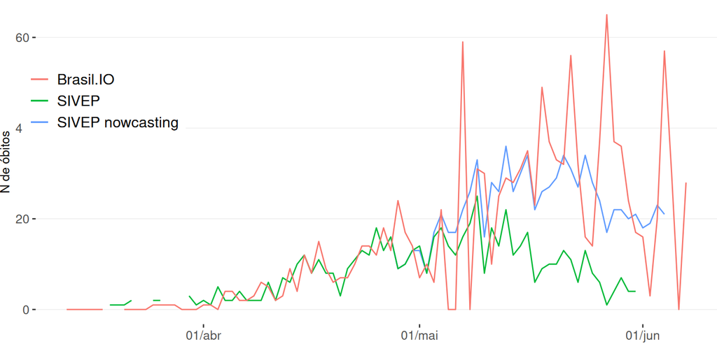

### Casos SRAG por evolução e hospitalização na SIVEP

O total de óbitos acumulados na base do Brasil.IO é 1235. Os totais e óbitos de residentes em Recife na base SIVEP é menor do isso. No entanto, o valor do Brasil.IO até dia 04/06/2020 é de 1177. compatível com o acumulado das estimativas de nowcasting, que vão até este dia. Esta estimativa é de 1076, com intervalo entre 796 e 1484 .

#### Casos de residentes no município

Recife casos SRAG de residentes, classificados por hospitalização e evolução, base SIVEP nacional do MS, 07/06/2020

|  | Alta | Óbito | ignorado | NA | Total |
| --- | --- | --- | --- | --- | --- |
| Hospitalizado | 225 | 504 | 59 | 1756 | 2544 |
| Não hospit | 1 | 55 | 0 | 76 | 132 |
| Ignorado | 1 | 0 | 1 | 12 | 14 |
| NA | 0 | 52 | 0 | 17789 | 17841 |
| Total | 227 | 611 | 60 | 19633 | 20531 |

#### Casos notificados no município

Recife casos SRAG notificados no município, classificados por hospitalização e evolução, base SIVEP nacional do MS, 07/06/2020

|  | Alta | Óbito | ignorado | NA | Total |
| --- | --- | --- | --- | --- | --- |
| Hospitalizado | 522 | 832 | 106 | 2540 | 4000 |
| Não hospit | 3 | 129 | 1 | 101 | 234 |
| Ignorado | 1 | 2 | 1 | 16 | 20 |
| NA | 1 | 75 | 0 | 184 | 260 |
| Total | 527 | 1038 | 108 | 2841 | 4514 |

# João Pessoa

## Casos e óbitos SRAG

### Comparação de óbitos nas duas bases e nowcasting SIVEP

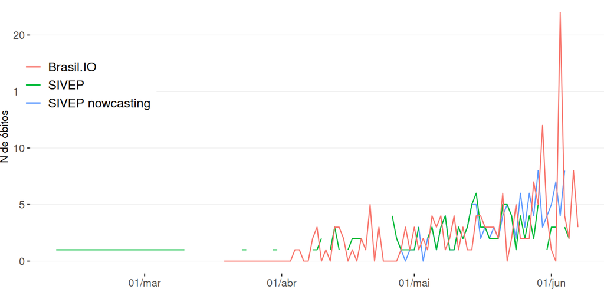

### Casos SRAG por evolução e hospitalização na SIVEP

O total de óbitos acumulados na base do Brasil.IO é 170. Os totais e óbitos de residentes em João Pessoa na base SIVEP é menor do isso. No entanto, o valor do Brasil.IO até dia 04/06/2020 é de 157. compatível com o acumulado das estimativas de nowcasting, que vão até este dia. Esta estimativa é de 160, com intervalo entre 120 e 275 .

#### Casos de residentes no município

João Pessoa casos SRAG de residentes, classificados por hospitalização e evolução, base SIVEP nacional do MS, 07/06/2020

|  | Alta | Óbito | ignorado | NA | Total |
| --- | --- | --- | --- | --- | --- |
| Hospitalizado | 96 | 121 | 7 | 266 | 490 |
| Não hospit | 10 | 10 | 1 | 47 | 68 |
| Ignorado | 2 | 2 | 0 | 9 | 13 |
| NA | 3 | 2 | 0 | 17634 | 17639 |
| Total | 111 | 135 | 8 | 17956 | 18210 |

#### Casos notificados no município

Jaão Pessoa casos SRAG notificados no município, classificados por hospitalização e evolução, base SIVEP nacional do MS, 07/06/2020

|  | Alta | Óbito | ignorado | NA | Total |
| --- | --- | --- | --- | --- | --- |
| Hospitalizado | 119 | 139 | 10 | 335 | 603 |
| Não hospit | 14 | 13 | 1 | 55 | 83 |
| Ignorado | 3 | 2 | 0 | 12 | 17 |
| NA | 3 | 1 | 1 | 19 | 24 |
| Total | 139 | 155 | 12 | 421 | 727 |

# Conclusões preliminares

- Total de óbitos reportados pelo Brasil.IO pode ser maior que o registrado no SIVEP-Gripe. Quando acontece, se dá pelo maior número de óbitos nas últimas semanas ou dias, nos dados do Brasil.IO. A diferença pode acontece pelo maior atraso de notificação de óbitos na SIVEP do que nos boletins. É possível também que haja óbitos que não são lançados no SIVEP (p.e.x que aconteceram no domicílio). Embora menos provável, é possível ainda que óbitos de residentes em outro municípios sejam contabilizados, especialmente em grandes cidades, para onde muitas pessoas de cidades menores se dirigem, em busca de tratamentos. Estas hipóteses não são excludentes.
- Caso a diferença seja causada por atraso de notificação, seria esperado que o total de óbitos estimados pelo nowcasting se aproximasse do total reportado no boletim. É o que acontece.
- Brasil.IO soma os óbitos anunciados pelas secretarias a cada dia. A evolução destes números pela data do boletim são afetadas por fatores administrativos. Um melhor acompanhamento da pandemia é feito usando como data de referência a data do evento epidemiológico (primeiros sintomas para casos e data do óbito para óbitos).